# Notebook

**Research Question:** "Across the full r/covidlonghaulers and r/dysautonomia corpora, what — if anything — predicts whether Mestinon (pyridostigmine) helps a given person?"

## Abstract

Mestinon (**pyridostigmine**) is an off-label mainstay for POTS / dysautonomia and one arm of the NIH **LIFT** Long COVID trial. We extracted first-person Mestinon reports from **two independent Reddit corpora** — full r/covidlonghaulers (n=429) and r/dysautonomia (n=406) — plus an earlier 2020–22 subset of the Long COVID corpus shown only for continuity, and aggregated to one outcome per user. The per-user positive rate is **~53%** in both and statistically indistinguishable from a coin-flip. Mestinon reliably helps **about half**, regardless of population.

## 1 · The question

Mestinon helps about half the people who try it (we establish that below, in two independent corpora). The useful question is therefore not *"does it work?"* but *"can we tell in advance who it works for?"* — the subtype-matrix question. If a symptom profile, a co-medication, or a dose pattern separated responders from non-responders, that would be directly actionable for triaging who to put on it (or who to enroll in a trial like LIFT). This notebook tests that across two large corpora and checks whether any predictor **replicates** — the only signal worth trusting at this noise level.

**Mestinon per-user positive rate (two independent corpora + nested 2020-22 subset)**

| Corpus | Reports | Users | Positive | 95% CI | vs chance (p) |
| --- | --- | --- | --- | --- | --- |
| r/covidlonghaulers (full, ~2M) | 1526 | 429 | 53% | 48%-58% | 0.21 |
| r/dysautonomia | 1217 | 406 | 53% | 48%-58% | 0.21 |
| r/covidlonghaulers (2020-22 slice, subset of full) | 181 | 49 | 55% | 41%-68% | 0.57 |

## 2 · Baseline: Mestinon helps ~half, everywhere

The first thing the data does is replicate itself. Two **independent** corpora — a Long COVID community (n=429) and a dysautonomia community (n=406) — both land at 53% positive, neither separable from a 50% coin-flip. (The 2020–22 slice is a *subset* of the full Long COVID corpus, not independent evidence; it is shown only to confirm the estimate is stable over time.) Each independent sample has ~400 users, so this is not small-sample noise.

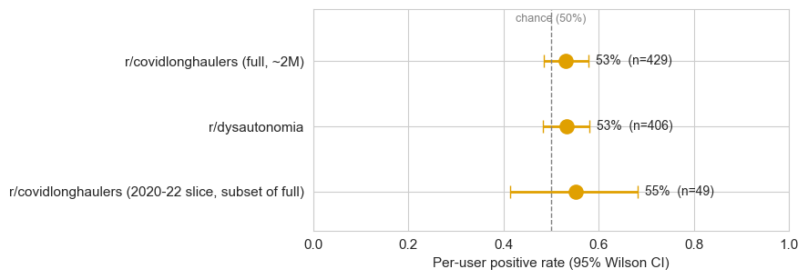

**What this shows:** every corpus sits on or just above the coin-flip line, CIs crossing 50%. Mestinon's ~53% positive rate is one of the most reproducible numbers in this whole project — and it is a *split*, not a win.

## 3 · The predictive model

If we cannot raise the average, can we at least find *who* lands on the positive side? We fit a per-user logistic regression on the two large corpora, predicting a positive outcome from features that are independent of the sentiment label: **symptom clusters** (autonomic, exertional, neuromuscular, GI), **co-medications** (LDN, beta-blocker, midodrine, fludrocortisone, ivabradine, salt/electrolytes), a **dose mention**, overall **posting volume**, **how many times** the user reported on Mestinon, and the **year** of first mention. Each feature is detected by scanning all of a user's posts.

**Full r/covidlonghaulers** n=429, McFadden pseudo-R²=0.086, model LLR p=4.5e-06

|  | OR (95% CI) | p |
| --- | --- | --- |
| dose | 1.61 (0.82-3.18) | 0.167 |
| sx_exertional | 1.57 (0.90-2.76) | 0.112 |
| med_salt | 1.53 (0.94-2.49) | 0.089 |
| year | 1.37 (1.17-1.59) | 0.000 |
| med_florinef | 1.34 (0.60-2.99) | 0.480 |
| sx_autonomic | 1.14 (0.58-2.23) | 0.706 |
| n_reports | 1.11 (1.03-1.20) | 0.006 |
| sx_neuromuscular | 1.02 (0.62-1.65) | 0.952 |
| sx_gi | 0.90 (0.55-1.47) | 0.672 |
| log_posts | 0.87 (0.72-1.04) | 0.127 |
| med_ivabradine | 0.79 (0.46-1.36) | 0.393 |
| med_betablocker | 0.74 (0.45-1.21) | 0.234 |
| med_ldn | 0.71 (0.43-1.19) | 0.193 |
| med_midodrine | 0.61 (0.32-1.16) | 0.134 |

**r/dysautonomia** n=406, McFadden pseudo-R²=0.058, model LLR p=0.0035

|  | OR (95% CI) | p |
| --- | --- | --- |
| sx_exertional | 1.50 (0.90-2.50) | 0.118 |
| sx_autonomic | 1.43 (0.63-3.25) | 0.396 |
| med_salt | 1.33 (0.79-2.25) | 0.283 |
| med_ldn | 1.22 (0.66-2.26) | 0.534 |
| sx_gi | 1.21 (0.76-1.92) | 0.418 |
| n_reports | 1.13 (1.04-1.24) | 0.006 |
| dose | 1.01 (0.59-1.70) | 0.981 |
| year | 0.97 (0.88-1.06) | 0.492 |
| med_ivabradine | 0.95 (0.55-1.63) | 0.841 |
| sx_neuromuscular | 0.89 (0.48-1.66) | 0.718 |
| med_betablocker | 0.86 (0.54-1.37) | 0.527 |
| med_florinef | 0.78 (0.46-1.34) | 0.365 |
| log_posts | 0.74 (0.59-0.93) | 0.008 |
| med_midodrine | 0.56 (0.34-0.92) | 0.022 |

**What this means:** both models are statistically significant overall, yet both explain only a sliver of the variance (pseudo-R² 0.06–0.09). In plain terms: knowing a patient's symptoms, co-meds, dose, and posting history barely moves your guess about whether Mestinon will help them above the 53% base rate.

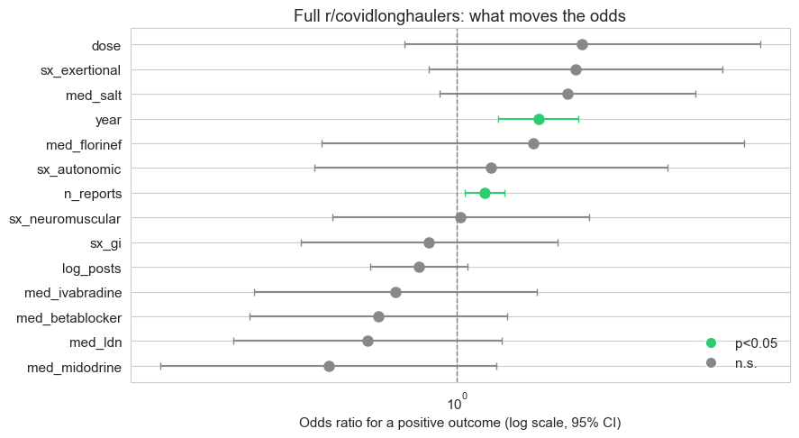

**What this shows:** only **year** (later = more positive) and **n_reports** (more posts about it = more positive) clear significance, and both are confounded (see next section). Everything clinically actionable — symptom clusters, co-meds, dose — straddles OR=1.

## 4 · The only thing worth trusting: what replicates

At a 53% base rate with this much noise, a single-corpus p-value means little. The real test is whether an effect shows up the **same way in both independent corpora**. Plotting each feature's odds ratio in covidlonghaulers against its odds ratio in dysautonomia: features near the dashed lines (OR=1) do nothing; features in the top-right or bottom-left quadrants point the same direction in both.

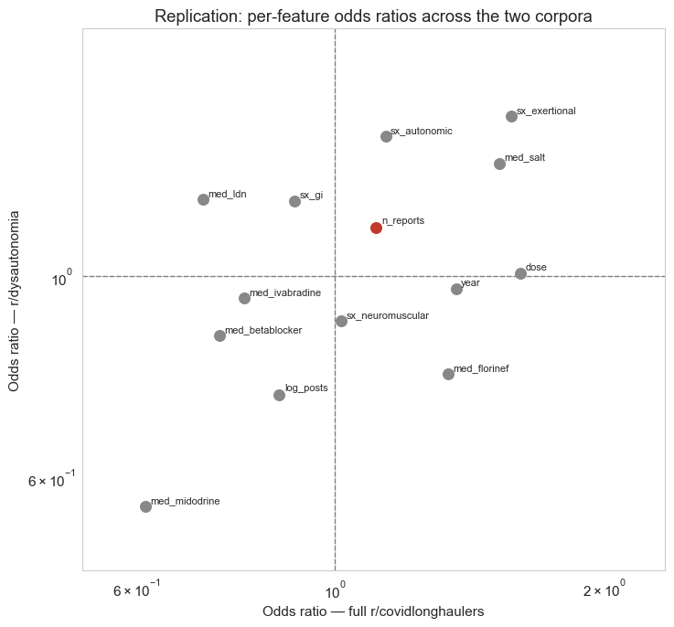

## 5 · Combining the corpora: does the exertional lead survive pooling?

One honest caveat first: the **unadjusted** exertional odds ratios (the 2×2 association below) are *weaker* than the multivariable ORs in §3 — 1.35 and 1.13, versus 1.57 and 1.50. The regression inflates the exertional coefficient by adjusting for features that are negatively associated with response (midodrine, heavy posting). What we pool here is the plain, unadjusted association.

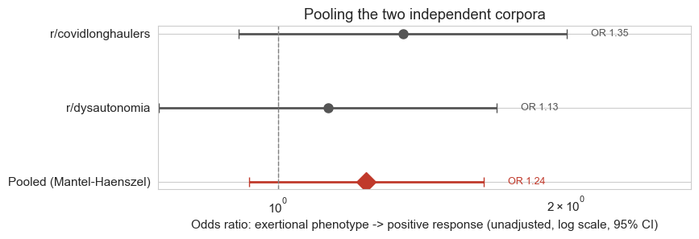

## 6 · Counterintuitive findings worth investigating

**The headline is the null.** With ~835 users across two corpora and a dozen features, we explain only 6–9% of the variance. That is the counterintuitive result for anyone expecting a clean "responder profile": **whether Mestinon helps you is, as far as this text reveals, close to idiosyncratic.** The community's lived experience says the same thing — for every confident "miracle for my POTS" there is a "did nothing for me."

(`year` predicts in covidlonghaulers but not dysautonomia — a Long-COVID-specific drift in how the drug was discussed as the community matured, not a property of the drug. We do not over-read single-corpus effects.)

## 7 · Conclusion

After two independent corpora and ~2.3 million posts, the answer to "what predicts whether Mestinon helps someone" is: **very little that you could use in a clinic.** The drug helps a remarkably stable ~53% of the dysautonomia and Long COVID patients who try it — no better than a coin-flip against a 50% null, and far short of low-dose naltrexone's ~65%. None of the obvious candidate predictors — symptom subtype, co-medications, dose, demographics-by-proxy — separates responders from non-responders in a way that replicates across both large corpora. The two statistically significant signals are either an artifact of reverse causation (post count) or population-specific drift (year).

The single honest lead is that **exercise-intolerant / exertional-phenotype patients may respond slightly more often** — directionally consistent across both corpora and mechanistically sensible — but pooling the two independent samples leaves it non-significant (OR 1.24, p=0.14), so it is not strong enough to act on without a prospective test. If we were advising the LIFT trial, the takeaway would be: do **not** expect a clean responder subtype to fall out of symptom history; if anything, enrich for the exertional/preload-failure phenotype and measure it directly. For a patient asking today, the data supports an honest "**it helps about half of people, we cannot tell in advance if you are one of them, and it is reasonable to try and stop if it does nothing in a few weeks.**" That is a less satisfying answer than a predictive subtype — but it is the one the data actually supports, and pretending otherwise would manufacture a profile that does not replicate.

What we can and cannot say

| Claim | Strength | Evidence |
| --- | --- | --- |
| Mestinon helps ~half who try it | **Strong** | 53% (n=429) & 53% (n=406), two independent corpora |
| It is not distinguishable from chance / weaker than LDN | **Strong** | binomial p>0.2 both; LDN ~65% (p<1e-6) |
| Symptom subtype / co-meds / dose predict response | **Refuted** | flat ORs, no replication, pseudo-R² 0.06-0.09 |
| Exertional phenotype responds slightly more | **Not supported when pooled** | pooled (MH) OR 1.24, p=0.14 (n.s.); only approaches significance (p=0.055) under full adjustment |
| Heavy posters / later years respond more | **Artifact** | reverse causation; single-corpus only |

## Research limitations

- **No control group** — a 53% positive rate has no placebo arm to beat; "helps half" is descriptive, not an efficacy estimate.
- **Sentiment ≠ efficacy** — we measure how people describe outcomes, not clinical endpoints.
- **Reverse causation** — engagement features (post count) are downstream of response, not predictors; we flag but cannot fully remove this.
- **Selection / reporting / survivorship** — posters skew severe, persistent, and dramatic-outcome; non-events and quiet recoveries are under-represented.
- **Confounding** — users take many things at once; feature flags are co-mention, not controlled exposure.
- **Multiple comparisons** — ~14 features × 2 corpora; we lean on cross-corpus replication rather than single p-values precisely because of this.
- **Text-mined features** — symptom/co-med flags are keyword presence in a user's history, not validated phenotypes; misclassification attenuates real effects (so a true predictor could be hidden by noise).
- **Temporal & community differences** — covidlonghaulers (2020-2026, Long COVID) and dysautonomia (2011-2026, broader) are different populations; we treat replication across them as a feature, but they are not interchangeable.

These findings reflect reporting patterns in online communities, not population-level treatment effects. This is not medical advice.